# Homework 8

Shynggys Magzanov

30 10 2020

## Exercise 5.3.3.

### 1.

Let us recall the Ito’s formula which is represented as follows:

$$dV = \frac{\partial V}{\partial t} dV + \frac{\partial V}{\partial r} dr
+ \frac{1}{2} \frac{\partial^2 V}{\partial r^2} dr^2$$
Now let $V = e^{\alpha t} (r(t) - b)$, then we have

$$\begin{align*}
\frac{\partial V}{\partial t} &= \alpha e^{\alpha t} (r(t) - b)\\ \\
\frac{\partial V}{\partial r} &= e^{\alpha t}\\ \\
\frac{\partial^2 V}{\partial r^2} &= 0\\ \\
\end{align*}$$

By substituting obtained result into the Ito Formula, we get

$$\begin{align*}
dV &= \alpha e^{\alpha t} (r(t) - b) dt + e^{\alpha t} dr\\ \\
dV &= \sigma dW(t)
\end{align*}$$

Now let us integrate both sides from $t$ to $t + \Delta$,

$$\begin{align*}
e^{\alpha (t + \Delta)} [r(t+ \Delta) - b]
&= e^{\alpha t} (r(t) - b) + \sigma [ W(\Delta + t) - W(t)]\\ \\
r(t+ \Delta) - b
&= e^{- \alpha t} (r(t) - b) + e^{- \alpha (t+ \Delta)} \sigma [ W(\Delta + t) - W(t)]\\ \\
r(t+ \Delta) &= e^{- \alpha \Delta} r(t) + b(1 - e^{- \alpha \Delta})
+ \frac{\sigma}{\sqrt{2 \alpha}} \sqrt{1 - e^{-2 \alpha \Delta}} Z
\end{align*}$$

Where $Z \sim N(0, 1)$.

### 2. Now using the transition distribution obtained in the previous part we need to construct a random walk on time interval [0,T].

To begin with, let us store the values of $\alpha, b,\sigma$ into a $3$x$18$ matrix, where every column stores one possible combination of the three input parameters.  
Next, we define the function ‘OUproc’, based on what we obtained in part $1$ of this exercise. This function is called iteratively to calculate the values of $r(t)$ within the given time interval $[0,T]$ for a specified combination of all the input parameters.  
Lastly, $for$ loop is built to call the function for $3$x$3$x$2$=$18$ times for all the possible combinations of parameters, and the results are plotted with corresponding titles clarifying the $\alpha, b,\sigma$ combinations.

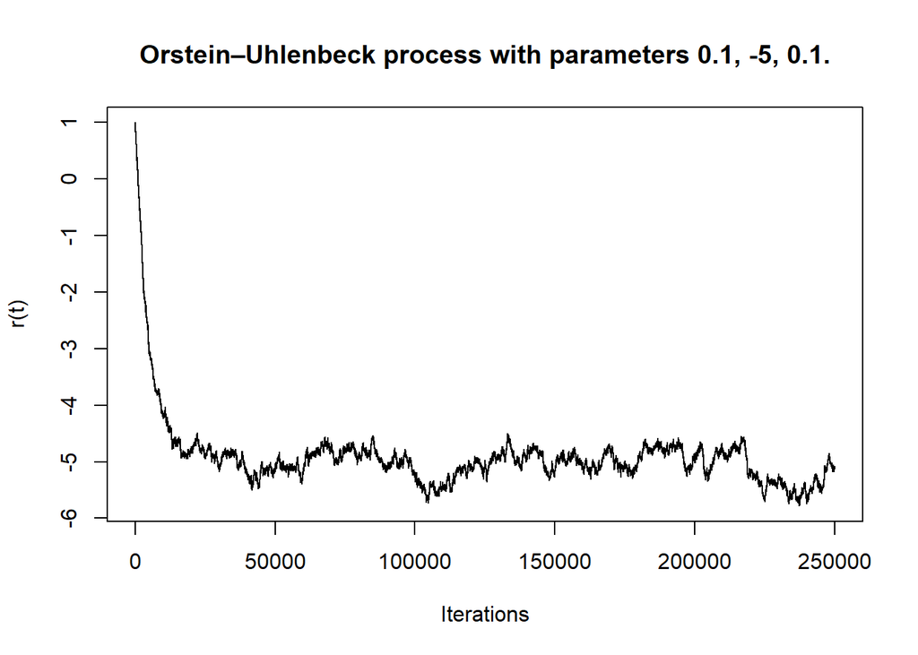

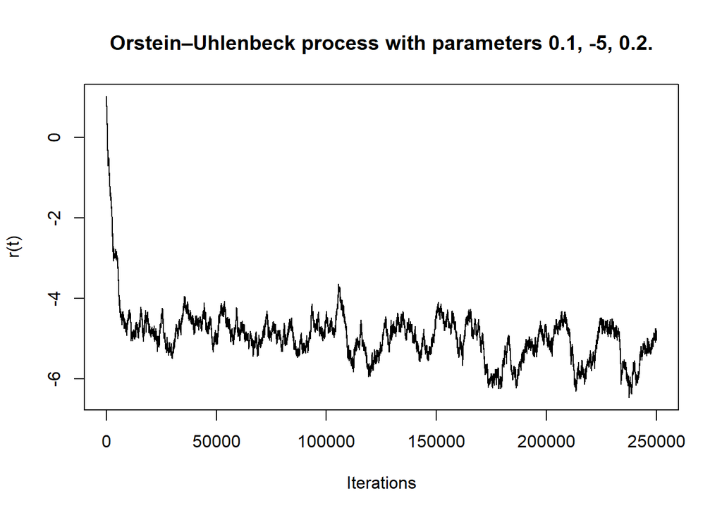

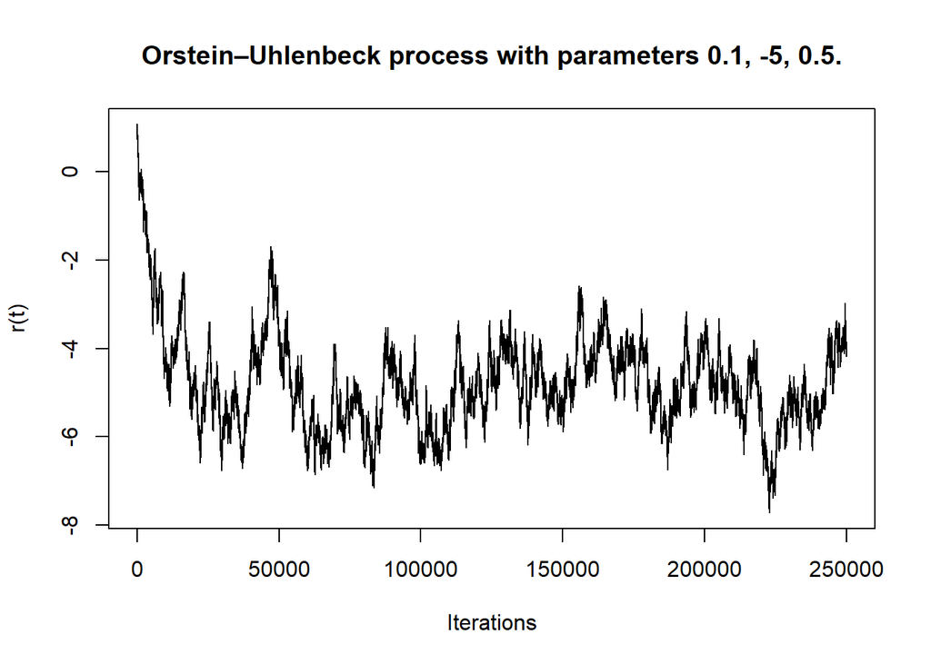

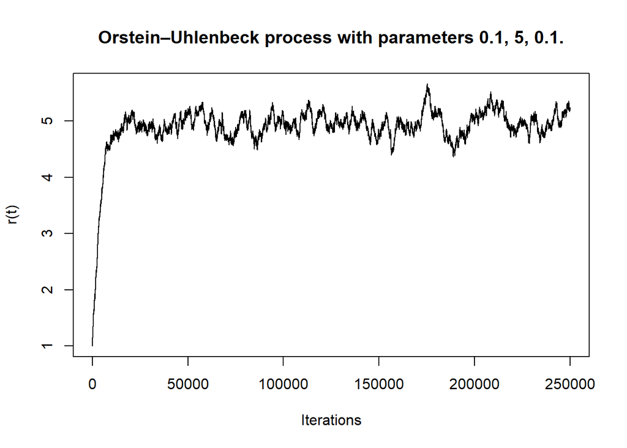

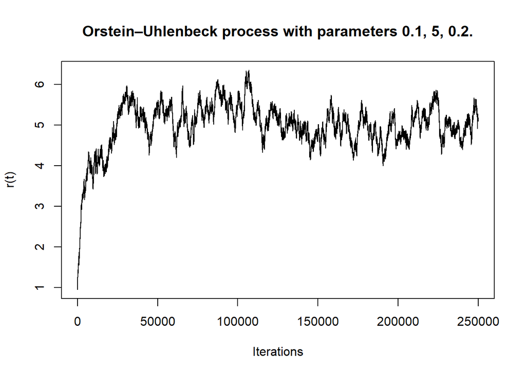

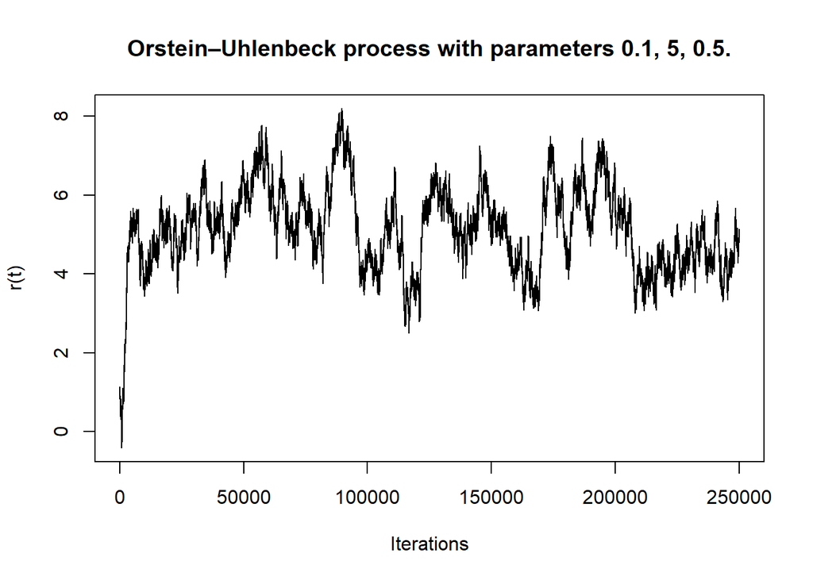

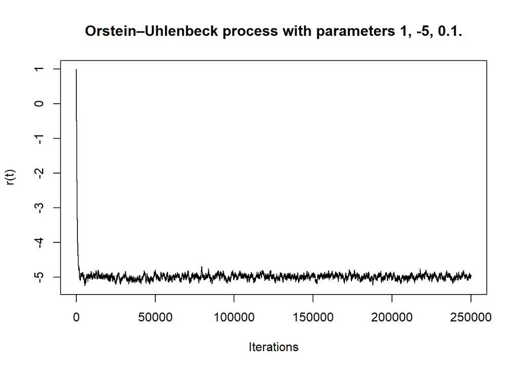

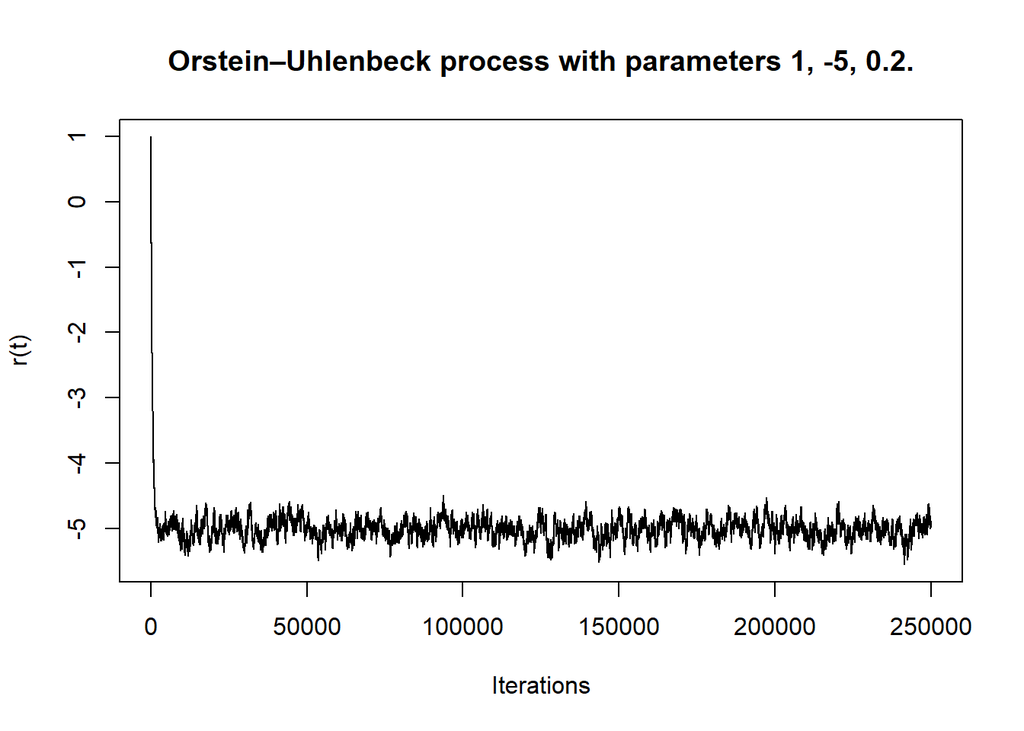

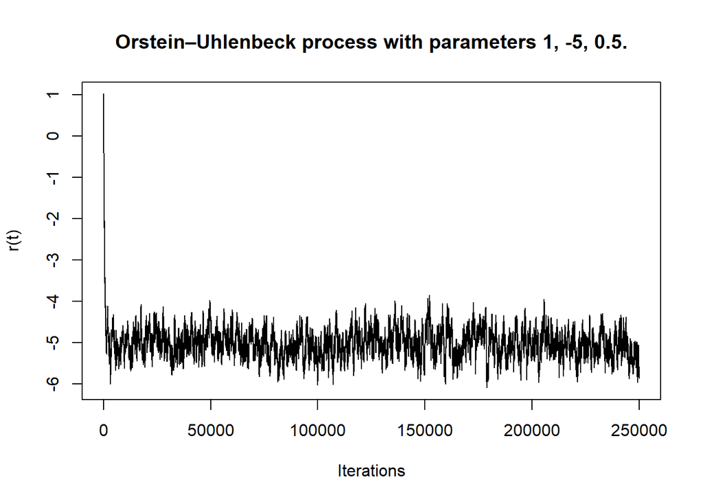

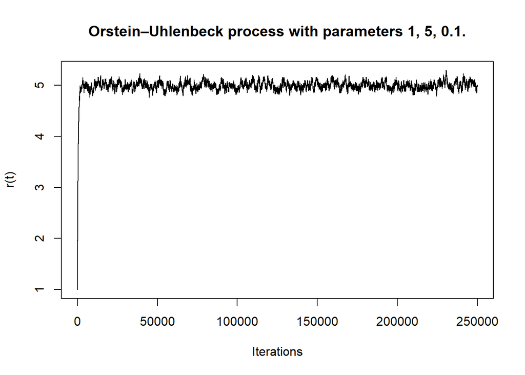

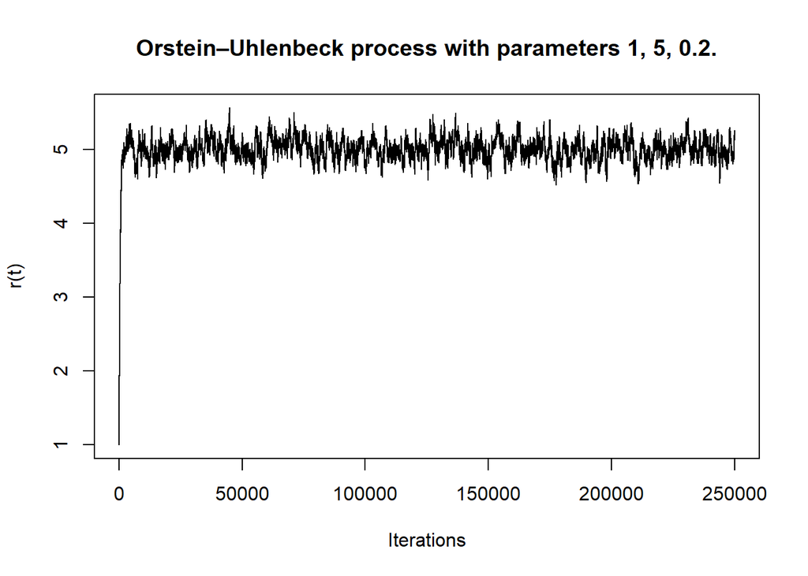

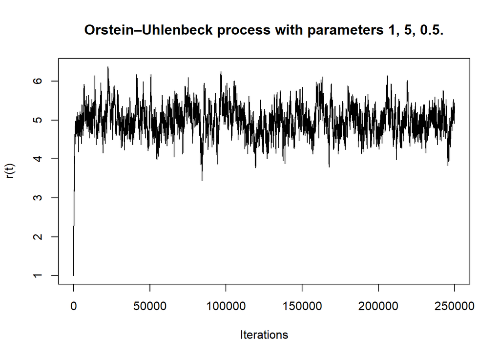

[6 more figures not shown]

```r
param.alpha <- c(rep(0.1, 6), rep(1, 6), rep(5, 6))
param.b <- rep(c(-5, -5, -5, 5, 5, 5), 3)
param.sigma <- rep(c(0.1, 0.2, 0.5), 6)

param <- rbind(param.alpha,param.b, param.sigma)

OUproc <- function(alpha, b, sigma, r.ini, T.t, Delta){
  r <- c()
  t <- 1
  r[1] <- r.ini

  for (t in 1:(T.t/Delta)){
    z <- rnorm(1)
    r[t + 1] <- exp(-alpha * Delta) * r[t] + b*(1 -  exp(-alpha * Delta)) +
      (sigma / sqrt(2*alpha)) * sqrt(1 - exp(-2 * alpha * Delta)) * z
    t <- t + 1
  }
  return(r)
}

i <- 1
for (i in 1:18){
  result <- OUproc (param[1, i], param[2, i], param[3, i], 1, 500, 1/500)
  plot(result, type = "l", xlab = "Iterations", ylab = "r(t)",
       main = paste0("Orstein–Uhlenbeck process with parameters ", param[1, i], ", ", param[2, i], ", ", param[3, i], "."))
}
```

As it can be seen from the graphs, the value of $\alpha$ presents the speed for $r(t)$ to hit $b$; while the value of $\sigma$ presents the volatility.

### 3. We need to use Euler–Maruyama method to approximate the simulation done in the previous part.

For this question let us fix input parameters as $\alpha=0.1, b=-5, \sigma=0.1$. First, let us implement the Random walk using the approximation.

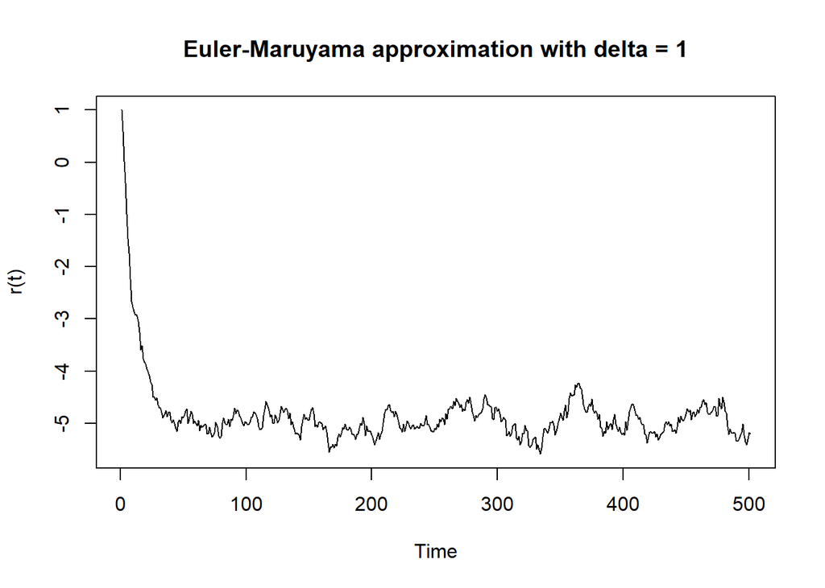

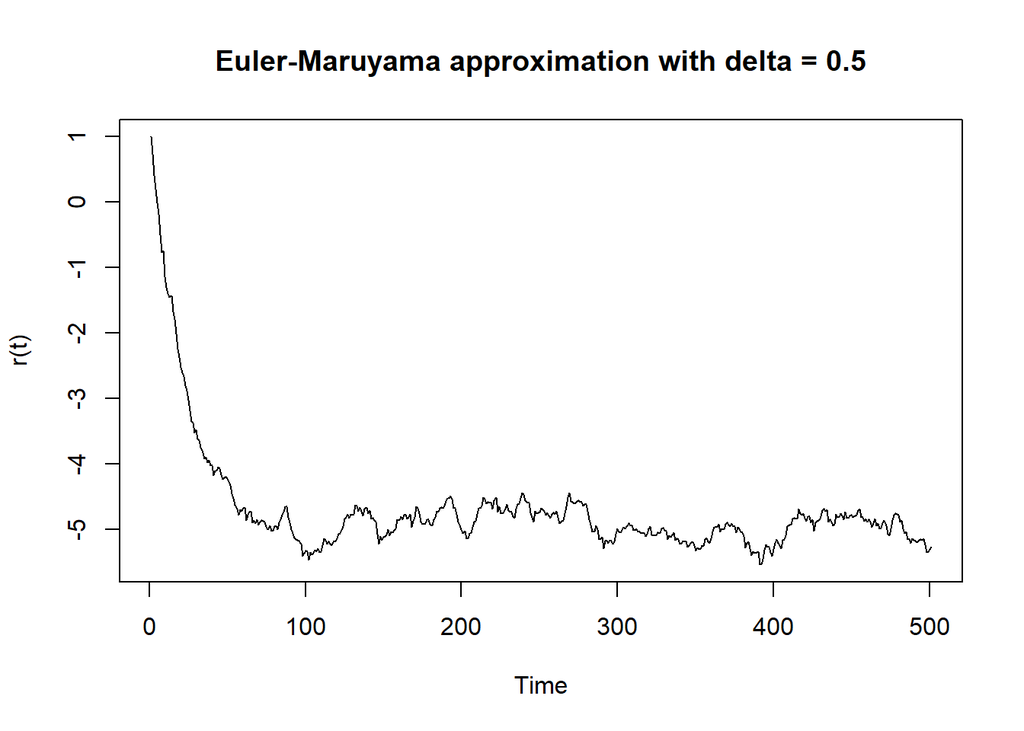

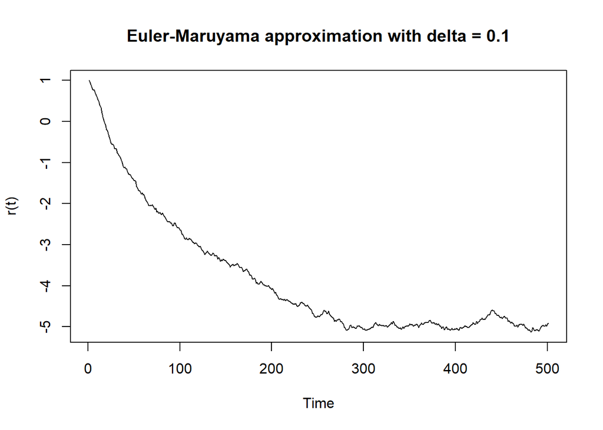

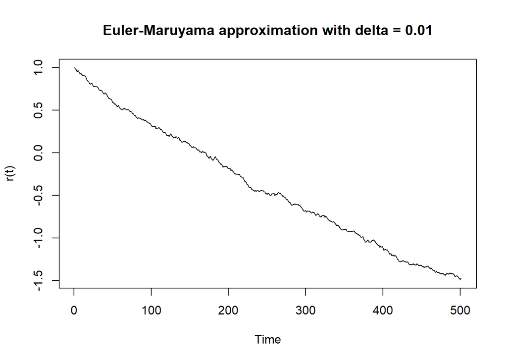

```r
param.alpha <- 0.1
param.b <- -5
param.sigma <- 0.1


EMapprox <- function(alpha, b, sigma, r.ini, T.t, dt){
  r <- c()
  t <- 1
  r[1] <- r.ini

  for (t in 1:(T.t)){
    dW <- rnorm(1,mean = 0, sd = sqrt(dt))
    r[t + 1] <- r[t] + alpha * (b - r[t]) * dt + sigma * dW
    t <- t + dt
  }
  return(r)
}

param.delta <- c(1, 0.5, 0.1, 0.01)

for (i in 1:length(param.delta)){
   result_2 <-  EMapprox(param.alpha, param.b, param.sigma, 1, 500, param.delta[i])
   plot(result_2, type = "l", xlab = "Time", ylab = "r(t)",
       main = paste0("Euler-Maruyama approximation with delta = " , param.delta[i] ))
}
```

As we can notice, as delta decreases, the approximation becomes worse. Now let us sample using Euler-Maruyama method and plot 4 histograms each corresponding to individual deltas chosen. Then we compare their densities to the true density.

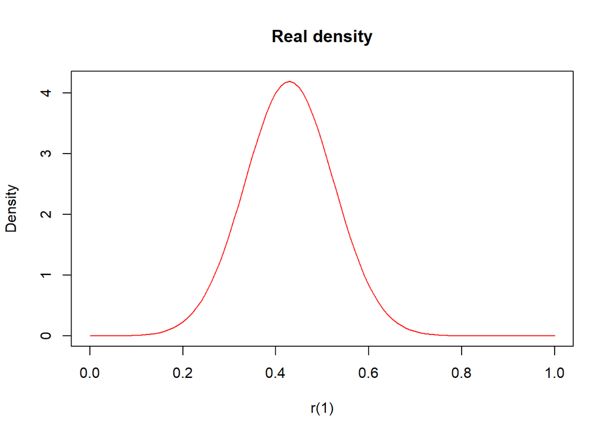

```r
plot_true2 <- function(alpha, sigma, b, delta = 1, initial = 1, ad = FALSE, para = 1){
  mean1 <- exp(-sigma * delta) * initial + b * (1-exp(-alpha * delta))
  sd1 <- sigma / sqrt(2 * alpha) * sqrt(1 - exp(-2 * alpha * delta))
  temp <- list(NULL, c(mean1 -5 * sd1, mean1 + 5 * sd1))
  curve(dnorm(x, mean = mean1, sd = sd1), col = 'red',
        xlim = temp[[para]],
        main = 'Real density', ylab = 'Density', xlab = 'r(1)', add = ad)
}

plot_true2(0.1, 0.1, -5)
```

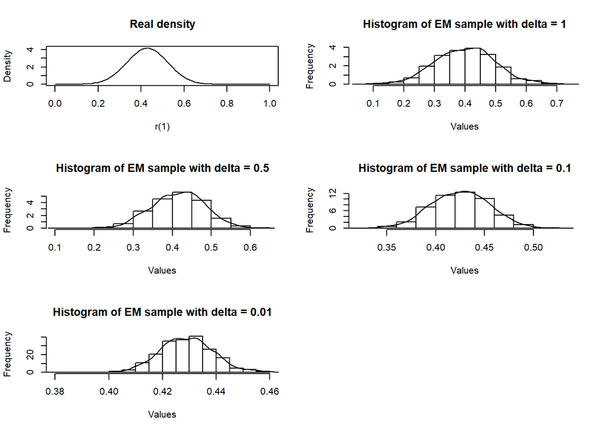

```r
EMsample <- function(alpha, sigma, b, delta, initial = 1, sample_size = 1000){
  n <- length(alpha)
  r_current <- matrix(rep(initial, sample_size), sample_size, n)
  alpha1 <- matrix(rep(alpha, sample_size), sample_size, n, byrow = TRUE)
  for (i in 1:(1/delta)){
    mean1 <- r_current + alpha1 * (b - r_current) * delta
    sd1 <- sigma * delta
    temp <- rnorm(sample_size * n, mean = t(mean1), sd = sd1)
    r_current <- matrix(temp, sample_size, n, byrow = TRUE)
  }
  return(r_current)
}

par(mfrow=c(3,2))
lines(plot_true2(0.1, 0.1, -5))
new_sample <- matrix(nrow = 1000, ncol = 4)
for (i in 1:length(param.delta)){
  new_sample[,i] <- EMsample(0.1, 0.1, -5, param.delta[i])
  hist(new_sample[,i], probability = TRUE, main = paste0("Histogram of EM sample with delta = ", param.delta[i]),
       xlab = "Values", ylab = "Frequency")
  lines(density(new_sample[,i]))
}
```

Again, notice that as delta decreases, the approximation provides worse results.

## Exercise 5.3.4

### 1) We need to figure out the distrubution of N(5) and it’s parameter.

Since we are given that it is a Poisson process, we already know that the number of events in an interval $(0,5]$ will be a Poisson random variable with a mean $\Lambda(5)=\int_{0}^{5}\lambda(t)dt$. Plugging in the intensity function to the integral and using Mathematica for integration, one can obtain:
$$\begin{align*}
\Lambda(5)=\int_{0}^{5}\sqrt{t} + \exp{-t}sin(2\pi t) dt = 7.607737136139157
\end{align*}$$

Thus, $N(5)\sim PN(7.607737136139157)$.

### 2) and 3) Now we need to write a function to simulate from this Poisson process and generate events 1000 times.

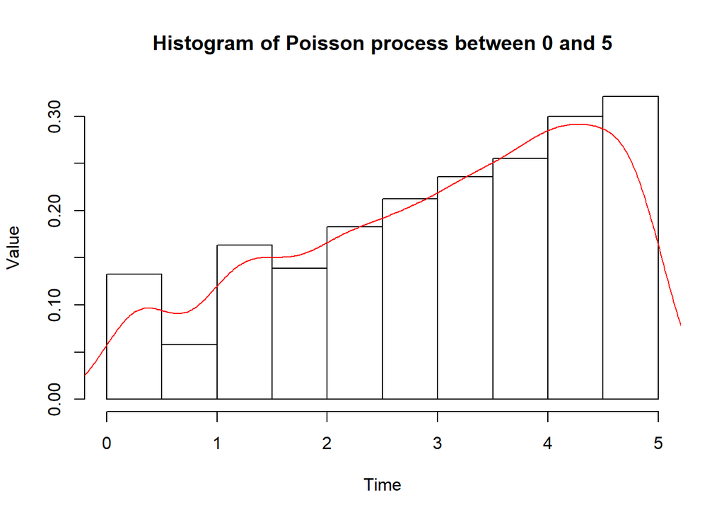

```r
rnhpp <- function(intensity, intmax, tmax) {
    n <- rpois(1, intmax)
    tt <- runif(n, 0, tmax)
    u <- runif(n)
    accept <- u < intensity(tt) / intmax
    sort(tt[accept])
}

intfun <- function(x) sqrt(x)+exp(-x)*sin(2*pi*x)

interval <- c(0,5)
intmax <- optimize(intfun, interval,
         maximum = TRUE,
         tol = .Machine$double.eps^0.25)
intmax <- intmax$maximum

pp <- unlist(replicate(1000, rnhpp(intfun, intmax, 5)))
hist(pp, probability = TRUE, main = paste0("Histogram of Poisson process between 0 and 5"),
     xlab = "Time", ylab = "Value")
lines(density(pp), col = "Red")
```

Above is the sampled Poisson process and it’s kernel density in red. Now let us plot $\lambda(t)/\int_{0}^{5}\lambda(t)dt$.

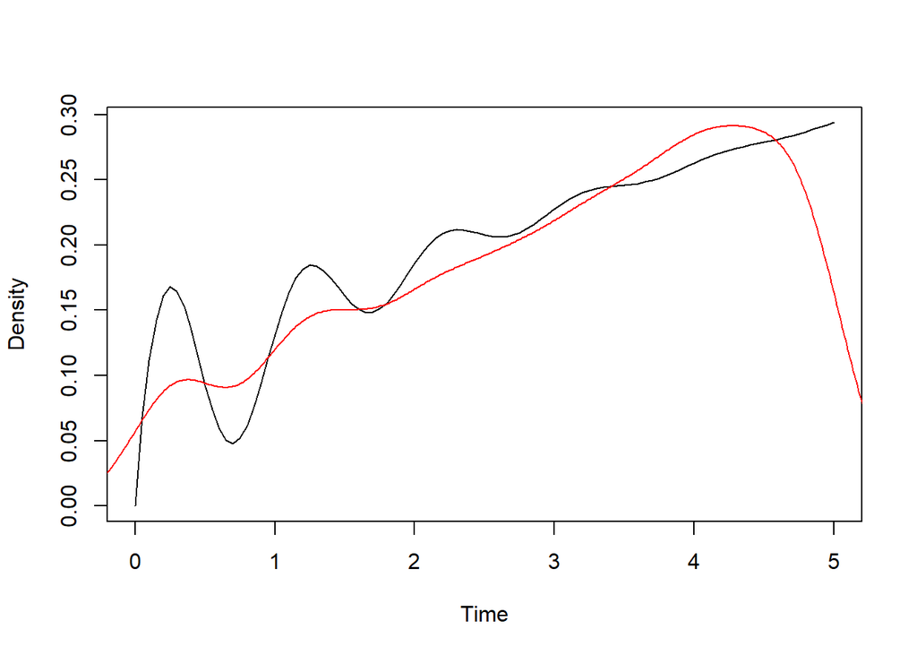

```r
fun2 <- function(x){
  return(intfun(x)/7.607737136139157)
}
curve(fun2, from = 0, to = 5, xlab = "Time", ylab = "Density")
lines(density(pp), col = "Red")
```

Here the black lines represents $\lambda(t)/\int_{0}^{5}\lambda(t)dt$, while red line represents kernel density.